# Ejercicio de Simulación Take Home 1

Manuel Camilo Corredor y Gabriela Narváez

2022-10-10

# Ejercicio de Simulación

librerias Requeridas

```r
library(ggplot2)
library(ggthemes)
```

## Punto 1

A continuacón se estipula unsa semilla para que el ejercicio pueda ser replicado y comparado, teneidno presente una distribucion normal de 511 valores

```r
set.seed(123)
a <- rnorm(n=511)
```

$$Z_t =-0.4Z_{t−1} +0.0872 Z_{t−2} +0.0614 \tilde{Z}_{t−3} + 50 + a_t,\ \
\ \ t=1,2,3,...,N.\\
Z_1 = 0\\ Z_2 = -2 \\ Z_3 = 3 \\a_t =perturbación$$

Teniendo lo valores iniciales se generan los datos realizando un reescalamiento del modelo a $\tilde{Z}$ donde:
$$Z_t =-0.4Z_{t−1} +0.0872 Z_{t−2} +0.0614 \tilde{Z}_{t−3} + a_t,\\
P.C=1+0.4B-0.0872B^2-0.0614B^3\\
E.C=1+0.4B-0.0872B^2-0.0614B^3=0$$

```r
N <- length(a)
phi1 <- -0.4
phi2 <- 0.0872
phi3 <- 0.0614
m <- 50/(1-phi1-phi2-phi3)
Z <- matrix(data = NA,nrow = N,ncol = 1)
Z[1] <-  0
Z[2] <-  -2
Z[3] <-  3
for(i in 4:N){
  Z[i] <- phi1*(Z[i-1]-m)+phi2*(Z[i-2]-m) +phi3*(Z[i-3]-m) +a[i]#SE ELIMINA CONTSTANTE
}

head(Z)
```

```
##           [,1]
## [1,]  0.000000
## [2,] -2.000000
## [3,]  3.000000
## [4,]  8.740858
## [5,]  6.816494
## [6,]  9.979620
```

```r
tail(Z)
```

```
##            [,1]
## [506,] 8.621823
## [507,] 6.771358
## [508,] 6.417942
## [509,] 8.747535
## [510,] 7.441930
## [511,] 8.127455
```

```r
mean(Z) #media
```

```
## [1] 7.999565
```

## Punto 2 Graficar la serie

creacion de Data Frame para la creación de Graficas por medio de ggplot

```r
Z1<- Z[-c(1:3)] #se elimnan los primeros tre valores datos
y <- c(1:508) #creación del vector x de la grafica

Z1 <- as.data.frame(cbind(y,Z1))
```

*Estadistica Descriptiva*

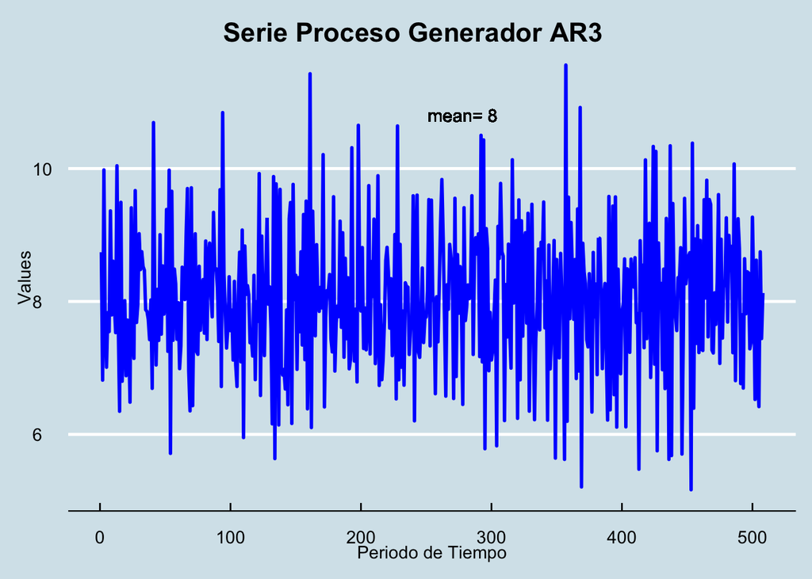

```r
#uso de ggplot y de la libreria ggthemes
ggplot(Z1) +
geom_line(aes(y=Z1,x=y), colour= "blue",size=1) +
ggtitle("                     Serie Proceso Generador AR3") +
geom_text(x=mean(Z1$Z)+270, y=10.8, label=paste("mean=",round(mean(Z1$Z),1)))+
labs(x="Periodo de Tiempo",y="Values" )+
theme_economist()+theme(axis.text = element_text(angle=0))
```

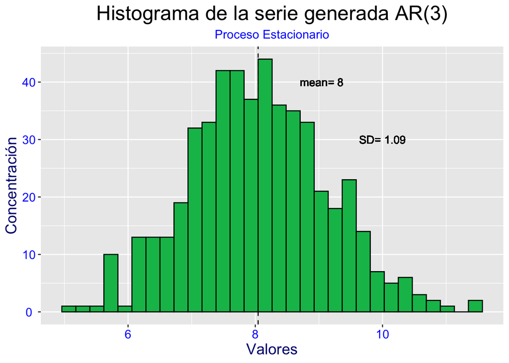

```r
ggplot(data = as.data.frame(Z1))+
  geom_histogram(mapping = aes(x=Z1),bins=30, color="black", fill="#00bc59")+
  geom_vline(aes(xintercept=mean(Z1)),linetype="dashed",color="black")+
  geom_text(x=mean(Z1$Z)+1, y=40, label=paste("mean=",round(mean(Z1$Z),1)))+
  geom_text(x=10,y=30,label=paste("SD=",round(sd(Z1$Z),2)))+
  ggtitle("Histograma de la serie generada AR(3)", subtitle="Proceso Estacionario") +
  labs(x="Valores",y="Concentración" )+
   theme(plot.title = element_text(hjust = 0.5,size=20))+
   theme(plot.subtitle = element_text(hjust = 0.5,size=12,color="blue"))+
   theme(axis.text.x =  element_text(hjust = 0.5,size=12,color="blue"))+
   theme(axis.text.y =  element_text(hjust = 0.5,size=12,color="blue"))+
   theme(axis.title.x =  element_text(hjust = 0.5,size=15,color="navy"))+
   theme(axis.title.y =  element_text(hjust = 0.5,size=15,color="navy"))
```

## Punto3 Procesos Teoricos AR3

```r
# importacion de la funcion AR3 construida para calcular cualquier escenario
source("Funciones/AR3.R")
```

### ACF y PACF Teorica

```r
AR3(-0.4,0.0872,0.0614,6) #Raices 1 y 2 Iguales
```

```
## [1] "G1^-1 =  -2.13834147900088 y G1 =  -0.375040148715287"
## [1] "G2^-1 =  -2.13834147900088 y G2 =  -0.375040148715287"
## [1] "G3^-1 =  2.85648751826234 y G3 =  0.350080297430573"
## [1] "El proceso es estacionario"
## [1] "raices iguales 1 y 2 "
## [1] "A1 =  0.985308231974202 , A2 =  -0.0868637970943515 , A3 =  0.0146917680257977"
## [1] "ACF Teorico"
##             [,1]
## [1,]  1.00000000
## [2,] -0.42271865
## [3,]  0.23033253
## [4,] -0.12127767
## [5,]  0.05662774
## [6,] -0.02015969
## [7,]  0.00390906
## [1] "PACF Teorico"
## [1] "phi11 es  -0.4227"
## [1] "phi22 es  0.0628770439405743"
## [1] "phi33 es  -0.00422289921164047"
## [1] "A1 MA =  0.925027719162014 , A2 MA =  -0.0359653273804469 , A3 MA =  0.0749722808379859"
## [1] "Psis"
##             [,1]
## [1,]  1.00000000
## [2,] -0.40000000
## [3,]  0.24720000
## [4,] -0.12446541
## [5,]  0.05896561
## [6,] -0.01926155
## [7,]  0.00306738
```

Como se evidencian en los anteriores valores este proceso AR 3 teroico presenta las raices 1 y 2 iguales

## Punto 4 Procesos Muestrales

### ACF Muestral

```r
source("Funciones/ACFfun0.R")
```

```r
ACF <- ACFfun0(Z,N/4) #función creada
#plot(ACF,type = "h" )
head(ACF)
```

```
##             [,1]
## [1,]  1.00000000
## [2,] -0.18070097
## [3,]  0.18688406
## [4,] -0.02140415
## [5,] -0.04953598
## [6,]  0.01877091
```

```r
acf(Z,plot = FALSE) #verificación con comando directo
```

```
##
## Autocorrelations of series 'Z', by lag
##
##      0      1      2      3      4      5      6      7      8      9     10
##  1.000 -0.181  0.187 -0.021 -0.050  0.019 -0.020  0.036 -0.002  0.009 -0.031
##     11     12     13     14     15     16     17     18     19     20     21
##  0.034 -0.073  0.028 -0.046  0.072 -0.063  0.058 -0.046  0.032  0.024 -0.024
##     22     23     24     25     26     27
##  0.073  0.008  0.022 -0.009  0.018 -0.041
```

```r
source("Funciones/PACFfun.R")
```

### PACF Muestral

```r
PACF <- PACFfun(ACF,N/4) #función creada
head(PACF)
```

```
##              [,1]
## [1,] -0.180700974
## [2,]  0.159437295
## [3,]  0.037965498
## [4,] -0.081719093
## [5,] -0.004837961
## [6,]  0.007187088
```

```r
pacf(Z,plot = FALSE) #verificación con comando directo
```

```
##
## Partial autocorrelations of series 'Z', by lag
##
##      1      2      3      4      5      6      7      8      9     10     11
## -0.181  0.159  0.038 -0.082 -0.005  0.007  0.034  0.006 -0.002 -0.034  0.029
##     12     13     14     15     16     17     18     19     20     21     22
## -0.055 -0.002 -0.025  0.066 -0.043  0.024 -0.024  0.023  0.037 -0.015  0.045
##     23     24     25     26     27
##  0.047  0.005 -0.013  0.011 -0.022
```

## Punto 5 Identifiación orden P

Para encontrar el p nos apoyaremos en los intervalos de confianza para ello usaremos el comando(qnorm) del paquete Normal stats que calcula los cuantiles de una distribución normal

para expandir la explicacion de los cuantiles lo graficaremos con ayuda del paquete tigerstats y el comando pnormGC

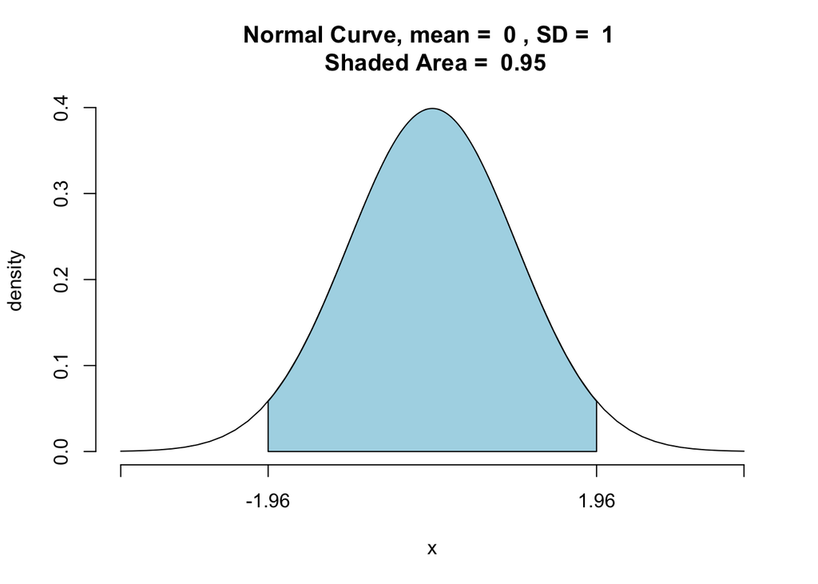

```
## [1] 0.9500042
```

```r
quantil <- qnorm(0.975,mean=0,sd=1) #defincioó del cuantil
quantil <- round(quantil,2) #redondeamos el valor a 1.96
pnormGC(c(-quantil,quantil),region="between",mean=0,
        sd=1,graph=TRUE)
```

con lo anterior crearemos los intervalos con una confianza del 95 sobre la grafica de las Autocorrelaciones Parciales

```r
lim_inf <- -quantil*sqrt(1/N) #limite inferior
lim_sup <- quantil*sqrt(1/N) #limite superior
```

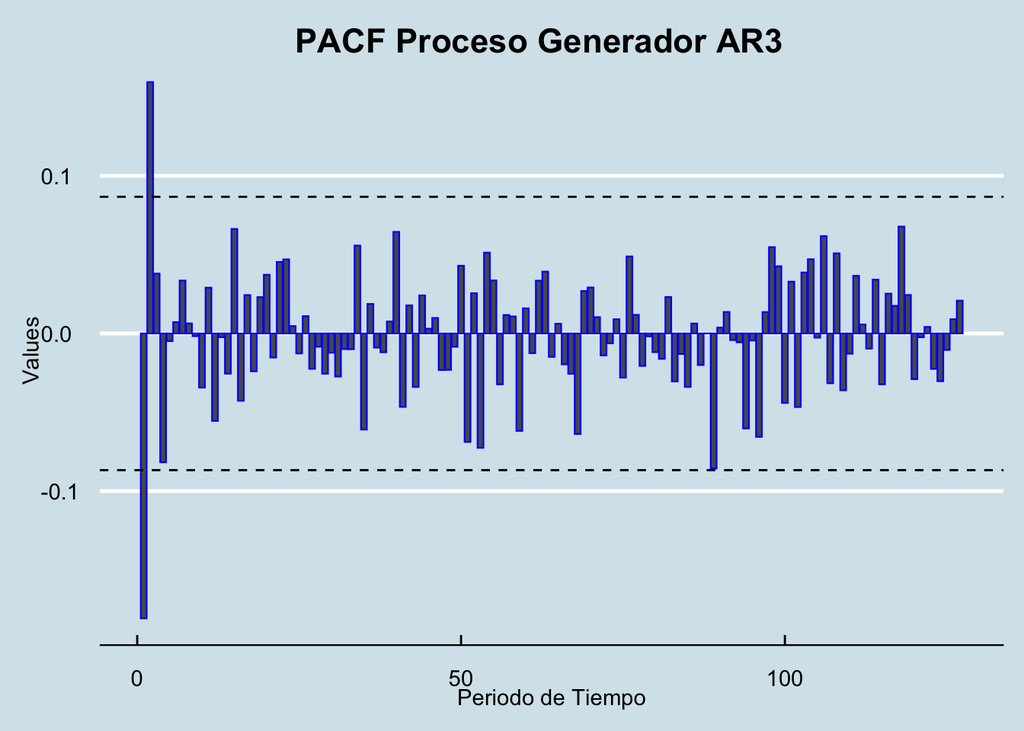

```r
y <- 1:length(PACF)
PACF1 <- as.data.frame(cbind(y,PACF))
ggplot(PACF1) +
geom_col(aes(y=PACF,x=y), colour= "blue",size=0.4) +
geom_hline(aes(yintercept=lim_sup),linetype="dashed",color="black")+
geom_hline(aes(yintercept=lim_inf),linetype="dashed",color="black")+
ggtitle("                     PACF Proceso Generador AR3") +
labs(x="Periodo de Tiempo",y="Values" )+
theme_economist()+theme(axis.text = element_text(angle=0))
```

Como se puede evidenciar en la grafica los unicos valores que no son 0 estadisticamente hablando son los primeros dos valores

```r
H <- length(PACF)
valor_p <- cbind()
for(p in 1:H){
  for(i in (p+1):H){
    if(PACF[p]>lim_inf&PACF[p]<lim_sup){
      valor_p[i] <- "dentro del intervalo"
    }
    else{
      valor_p[i] <- "fuera del intervalo"
    }
  }
}
#print(cbind(valor_p))#verificación para cada valor de la PACF
head(cbind(valor_p))
```

```
##      valor_p
## [1,] NA
## [2,] "fuera del intervalo"
## [3,] "fuera del intervalo"
## [4,] "dentro del intervalo"
## [5,] "dentro del intervalo"
## [6,] "dentro del intervalo"
```

## Punto 6

Aplicacion de la función arima() debido a que es una serie generada, solo tomaremos los ultimos 92 datos para realizar la verificación de ruido balnco en los residuales estimados

```r
Z2 <- Z[420:511] #se
modelillo <- arima(Z2, c(3,0,0))
residualcitos <- modelillo$residuals
head(residualcitos)
```

```
## [1] -0.7019561  1.6081465  0.3372120  0.1377202  1.1636708 -0.6694320
```

Calculo de la ACF de los residuales

```r
Na <- length(residualcitos)
Rho_residuales <- ACFfun0(residualcitos,(Na/4))
```

*Estadístico Q de Box- Pierce (1970)*
$$Q=(N-d-1)\sum_{k=1}^{[\dfrac{N}{4}]}(\hat{\rho_k}(\hat{a}))^2$$

```r
d <- 0
Q1 <- (Na-d-1)*sum(Rho_residuales^2)
Q1
```

```
## [1] 107.0735
```

*Estadístico Q’ de Ljung-Box (1978)*
$$Q=(N-d-1)*(N-d+1)\sum_{k=1}^{[\dfrac{N}{4}]}\dfrac{\hat{\rho_k}(\hat{a}))^2}{N-d+1-k}$$

```r
for(i in 1:(Na/4)){
  Q2 <- (Na-d-1)*(Na-d+1)*(sum(Rho_residuales**2))/(Na-d-1-i)
}

Q2
```

```
## [1] 146.4387
```

$H_0:$ los residuales estimados $\hat{a}$ˆ son ruido blanco,. $H_a:$ los residuales estimados $\hat{a}$ˆ no son ruido blanco.

```r
k <- (N/4)
ValorCritico <- qchisq(p = 0.95,df = k-1,FALSE)
ValorCritico
```

```
## [1] 154.0257
```

```r
if( ValorCritico >Q2 ) {
  "no se rechaza la hipotesis nula"
} else {
  "se rechaza la hipotesis nula"
}
```

```
## [1] "no se rechaza la hipotesis nula"
```